# Linear Regression

Hi All,

In the problem we are going to forecast the profit of an organization by looking into the R&D spend , Administration, Marketing Spend and the state in which the organization operates. As you can see here we are predicting a continuous value that means it becomes a regression problem.

At the end of or process we will find out how much profit an organization likely to make depend upon its spending on these areas.

Please try to do by own in jupyter notebook. If you have any issues please feel free to contact me. I will be happy to answer it.

# Importing all the necessary libraries for python

```python
#importing important libraries
import pandas as pd
import numpy as np
import matplotlib.pyplot as plt
import seaborn as sns
%matplotlib inline
```

Reading the source dataset via pandas data frame object.

1. Creating the X axis value for the correlation matrix
2. Creating the Y axis (profit)

```python
#Importing the dataset
#Importing independent variable
#Importing dependent

comp = pd.read_csv("C:/Users/deepak.rajak/Documents/Practice-Algo/1000_Companies.csv")
X = comp.values[:, 0:4]
Y = comp.values[:, 4]

comp.head()
```

|  | R&D Spend | Administration | Marketing Spend | State | Profit |
| --- | --- | --- | --- | --- | --- |
| 0 | 165349.20 | 136897.80 | 471784.10 | New York | 192261.83 |
| 1 | 162597.70 | 151377.59 | 443898.53 | California | 191792.06 |
| 2 | 153441.51 | 101145.55 | 407934.54 | Florida | 191050.39 |
| 3 | 144372.41 | 118671.85 | 383199.62 | New York | 182901.99 |
| 4 | 142107.34 | 91391.77 | 366168.42 | Florida | 166187.94 |

# Data Visualization

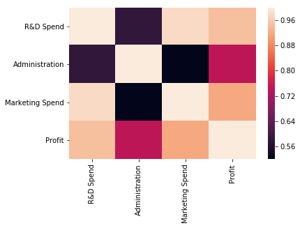

```python
#Data Visualization
#Building Correlation Matrix

sns.heatmap(comp.corr());
```

Converting state information into the Numerical Values. One Hot Encoding

```python
#Encoding Categorical data
from sklearn.preprocessing import LabelEncoder, OneHotEncoder
labelencoder = LabelEncoder()
X[:, 3] = labelencoder.fit_transform(X[:, 3])

onehotencoder = OneHotEncoder(categorical_features = [3])
X = onehotencoder.fit_transform(X).toarray()
print(X)
```

```
[[0.0000000e+00 0.0000000e+00 1.0000000e+00 1.6534920e+05 1.3689780e+05
  4.7178410e+05]
 [1.0000000e+00 0.0000000e+00 0.0000000e+00 1.6259770e+05 1.5137759e+05
  4.4389853e+05]
 [0.0000000e+00 1.0000000e+00 0.0000000e+00 1.5344151e+05 1.0114555e+05
  4.0793454e+05]
 ...
 [1.0000000e+00 0.0000000e+00 0.0000000e+00 1.0027547e+05 2.4192631e+05
  2.2714282e+05]
 [1.0000000e+00 0.0000000e+00 0.0000000e+00 1.2845623e+05 3.2165214e+05
  2.8169232e+05]
 [0.0000000e+00 0.0000000e+00 1.0000000e+00 1.6118172e+05 2.7093986e+05
  2.9544217e+05]]
```

Very Important to address the dummy variable issue

```python
#Avoiding dummy variable trap
X = X[:, 1:]
print(X)
```

```
[[0.0000000e+00 1.0000000e+00 1.6534920e+05 1.3689780e+05 4.7178410e+05]
 [0.0000000e+00 0.0000000e+00 1.6259770e+05 1.5137759e+05 4.4389853e+05]
 [1.0000000e+00 0.0000000e+00 1.5344151e+05 1.0114555e+05 4.0793454e+05]
 ...
 [0.0000000e+00 0.0000000e+00 1.0027547e+05 2.4192631e+05 2.2714282e+05]
 [0.0000000e+00 0.0000000e+00 1.2845623e+05 3.2165214e+05 2.8169232e+05]
 [0.0000000e+00 1.0000000e+00 1.6118172e+05 2.7093986e+05 2.9544217e+05]]
```

```python
#Splitting the data between train and test
from sklearn.model_selection import  train_test_split
X_train, X_test, Y_train, Y_test = train_test_split(X, Y, test_size= 0.2, random_state=0)
```

Now we have split the data between Test and Train in the ration of 20% and 80%

# Training the model

```python
#Fitting the liner regression model
from sklearn.linear_model import LinearRegression
regressor = LinearRegression()
regressor.fit(X_train, Y_train)
```

```
LinearRegression(copy_X=True, fit_intercept=True, n_jobs=1, normalize=False)
```

# Predicting

```python
#Predicting the model
y_pred = regressor.predict(X_test)
y_pred
```

```
array([ 89790.61532915,  88427.07187361,  94894.67836972, 175680.86725611,
        83411.73042088, 110571.90200074, 132145.22936439,  91473.37719686,
       164597.05380606,  53222.82667401,  66950.19050989, 150566.43987005,
       126915.20858596,  59337.8597105 , 177513.91053062,  75316.28143051,
       118248.14406603, 164574.40699902, 170937.2898107 , 182069.11645084,
       118845.03252689,  85669.95112229, 180992.59396144,  84145.08220145,
       105005.83769214, 101233.56772747,  53831.07669091,  56881.41475224,
        68896.39346905, 210040.00765883, 120778.72270894, 111724.87157654,
       101487.90541518, 137959.02649624,  63969.95996743, 108857.91214126,
       186014.72531988, 171442.64130747, 174644.26529205, 117671.49128195,
        96731.37857433, 165452.25779409, 107724.34331255,  50194.54176913,
       116513.89532179,  58632.4898682 , 158416.4682761 ,  78541.48521609,
       159727.66671743, 131137.87699644, 184880.70924516, 174609.0826688 ,
        93745.66352059,  78341.13383418, 180745.9043908 ,  84461.61490552,
       142900.90602903, 170618.44098397,  84365.09530839, 105307.3716218 ,
       141660.07290787,  52527.34340442, 141842.9626416 , 139176.27973195,
        98294.52669666, 113586.86790969, 126754.21895489, 152135.51985562,
        58864.51658955, 174285.5736113 , 124624.04380784, 169065.77658978,
        91279.33198209, 156170.37268962,  84307.26579366,  77877.75223097,
       120414.02421346,  93380.44273241, 139020.62514121, 143604.67103573,
       171148.30815368, 140082.97050131, 106369.71689747, 155641.43851388,
       140030.10330037, 110172.87893525,  69672.98677565,  88148.52068041,
       140133.59925093, 148479.09537887, 157916.63505257,  58532.94863141,
        93707.3842239 , 112646.37475705,  56556.1894366 , 107414.89996181,
       147352.80227752, 152144.10104034, 167808.11701784, 118750.25230713,
       120763.27666701, 139029.95295663, 157527.90934119, 121962.0621496 ,
        87091.32399736, 104792.91384333,  95335.22679185, 178389.52287436,
       181942.63776381, 109831.34945506, 165254.03344096, 167806.06491902,
       158002.44642543, 174782.86900956, 170196.77102699,  52302.18161612,
       176938.1159579 , 104751.83583865,  82710.31528805, 138890.52767844,
       144274.74675425, 161679.0183644 , 169662.05445895, 120450.9231013 ,
       158880.70799547, 110213.73252824, 169674.51532366,  60760.61300841,
       159036.99629068, 158169.44286048, 174511.70494475, 156294.79927784,
       103714.37583212,  85635.96237574, 141603.54878757, 165917.6915698 ,
       121182.03641977, 170751.87883894, 100505.77549411,  82097.51033128,
       178643.18879843, 101790.48384578,  70507.40958622,  90250.04230088,
        61247.4996268 ,  68912.1753452 ,  72775.81613475, 176914.08873124,
        89704.69244931, 129209.43730015,  92672.90938383,  88133.59175044,
       172836.33021619,  60893.62070014, 169015.8944601 , 166450.24453204,
       165425.54476415, 102170.5169499 , 181594.57928216,  73702.57942561,
        91267.42979668, 135791.54160195,  64922.802573  ,  71775.70235726,
        60603.91401515, 184288.61041916, 176286.69585945, 158907.75687039,
       141359.32216439, 154611.17928321,  58549.58863233,  90618.58407899,
       152885.51163925, 168398.05223805,  72485.36274539, 116064.24350667,
        80087.80697208, 149828.90896188, 116806.9595737 , 130191.48845161,
       174534.42670329, 293584.45948283, 146270.83174789, 150646.69178014,
        86107.47782247,  69967.20842246,  70096.78368773,  69033.69170769,
       120666.75708063,  89677.68014063, 166824.27091662, 125514.76626409,
        67209.67687466, 140930.69427702, 118544.30490695, 165897.61905906,
       168655.48652552, 147009.66805049, 141396.22104146, 109086.50634849])
```

```python
#calculation the coefficients
regressor.coef_
```

```
array([-8.80536598e+02, -6.98169073e+02,  5.25845857e-01,  8.44390881e-01,
        1.07574255e-01])
```

```python
#calculating the intercept
regressor.intercept_
```

```
-51035.22972402591
```

Calculatig the value of R square to check the accuracy of the model. Remember the value should be more closer to 1 for the ideal model

```python
#Evaluating the model
#Calculating the r squared value
from sklearn.metrics import r2_score
print("The accuracy of the liner model is: ", r2_score(Y_test, y_pred))
```

```
The accuracy of the liner model is:  0.9112695892268863
```

Finally we have done it. Our model accuracy is around 91% and which is quite good